# Лабораторная работа №3

Агентное моделирование

Софич Андрей Геннадьевич

safich05@mail.ru

Российский университет дружбы народов

2026-21-03

Докладчик

- Софич Андрей Геннадьевич

## Актуальность

- Провести ознакомлдение с агентным моделированием

## Цели и задачи

Изучить в теории и на практике возможности агентного моделирования.

## Выполнение лабораторной работы

Создаем рабочий каталог и инициализируем проект в julia

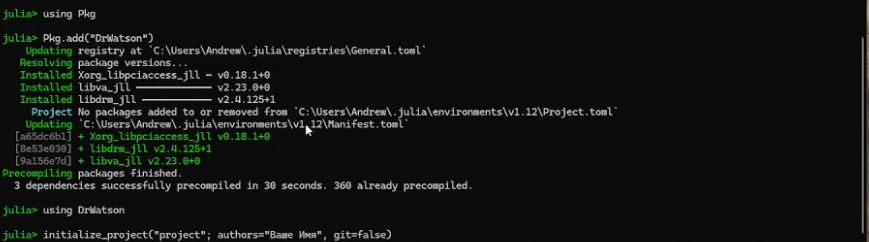

Инициализация проекта

Устанавилваем все необходимые пакеты (Agents)

[figure not shown]

Установка пакетов Agents

Устанавливаем дополнительные пакеты для работы с агентным моделированием

[figure not shown]

Загрузка доп. пакетов

Создаем файл в папке scr, в котором мы определим тип агента и функции шага модели

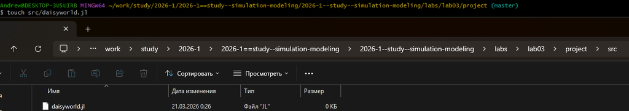

Создаем исполняемый файл в папке scripts и прописываем в нем код

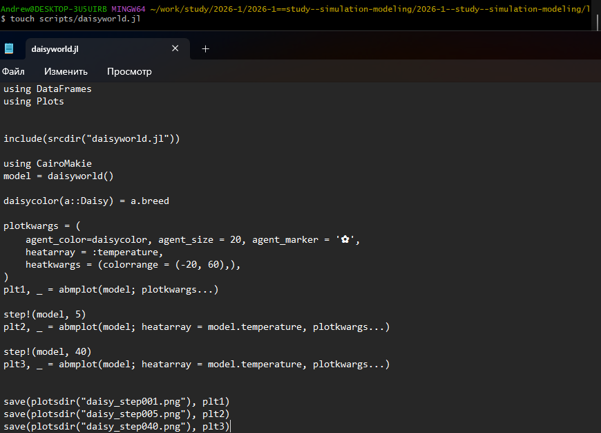

Создание исполняемого файла

Запускаем файл и анализируем тепловую карту, которая будет представлять собой температуру поверхности модели. Маргаритки будут отображаться черно-белыми в соответствии с их видом.

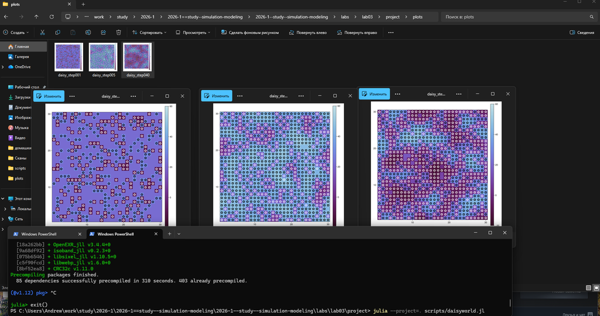

Тепловая карта - базовая визуализация

Преобразовываем код в произвольные стили, открываем jupyter файл и убеждаемся в правильной компиляции.

[figure not shown]

Код из jupyter notebook

Создаем файл с анимацией, прописываем в нем код и запускаем.

[figure not shown]

Создание и запуск анимации модели

Результат можно увидеть в папке plots или по ссылке в rutube:

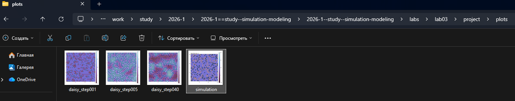

Результат

https://rutube.ru/video/fc59731ceb08176e1f6a8170228c0836/

Создаем, заполняем и запускаем файл, в котором наглядно показана динамика числа маргариток

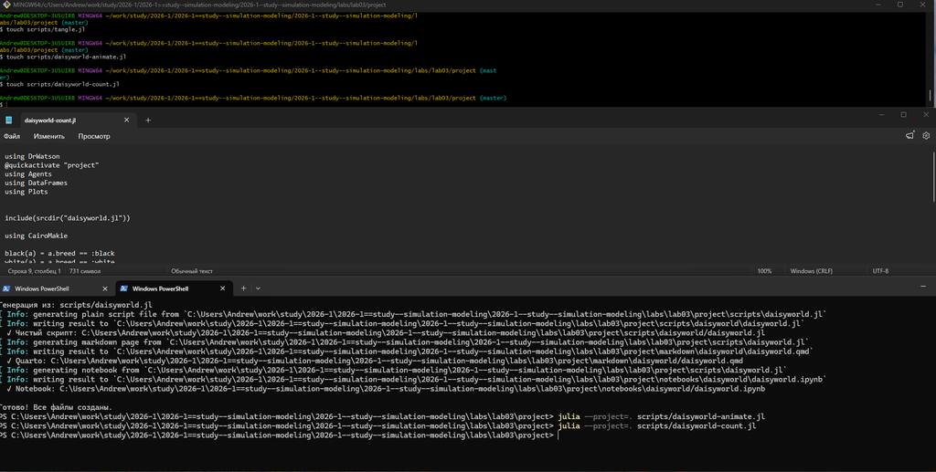

Файл с динамикой числа маргариток

Наглядно видим результат запуска файла.

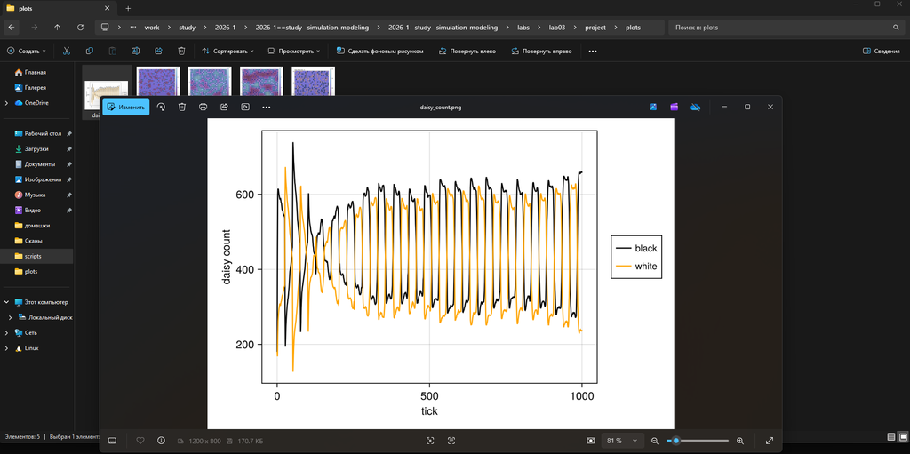

График динамики

Преобразовываем код в произвольные стили, открываем jupyter файл и убеждаемся в правильной компиляции.

[figure not shown]

Код из jupyter notebook

Создаем, заполняем и запускаем файл, который построит комплексный график изменения числа маргариток,температуры,альбедо в зависимости от модельного времени

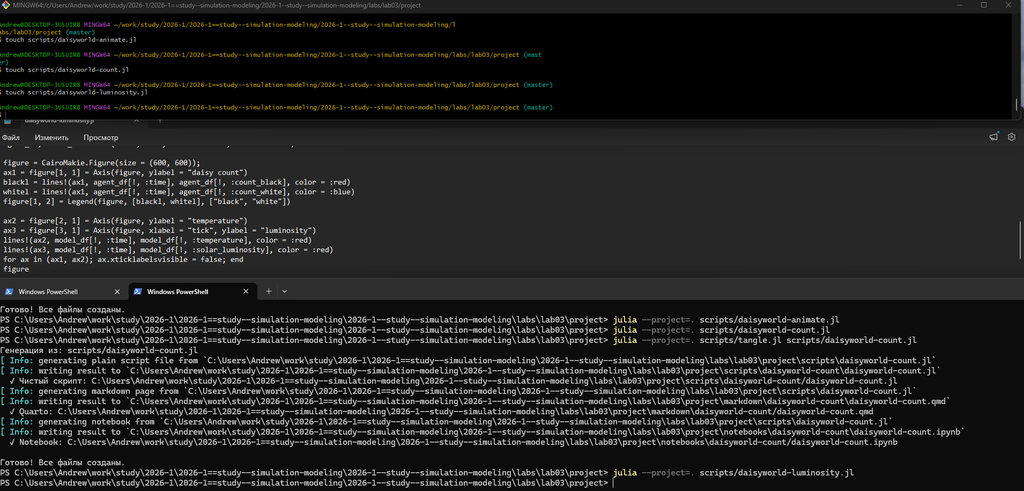

Создание файла с комплексным графиком

Заходим в папку plots и открываем наши графики, анализируем поведение модели

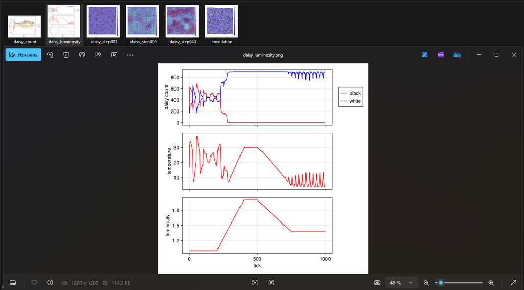

Комплексный график изменения числа маргариток

Преобразовываем код в произвольные стили, открываем jupyter файл и убеждаемся в правильной компиляции.

[figure not shown]

Код из jupyter notebook

Мы можем расширить базовую визуализацию за счет параметров. Для этого создаем новый файл, в котором прописываем параметры и на выходе получаем несколько троек графиков для каждого набора параметров

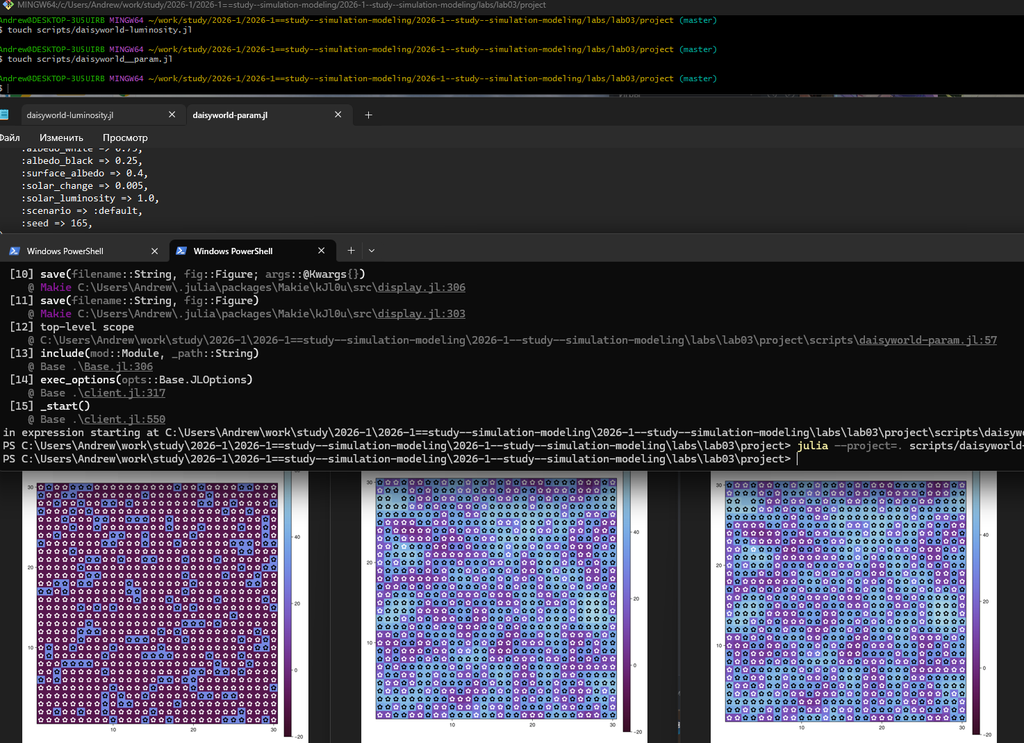

Базовая визуализация с параметрами

Преобразовываем код в произвольные стили, открываем jupyter файл и убеждаемся в правильной компиляции.

[figure not shown]

Код из jupyter notebook и еще одна тройка графиков

Создаем файл, в котором зависимо от заданого набора параметров можно построить график динамика числа маргаритов в зависимости от времени, заполняем и запускаем его

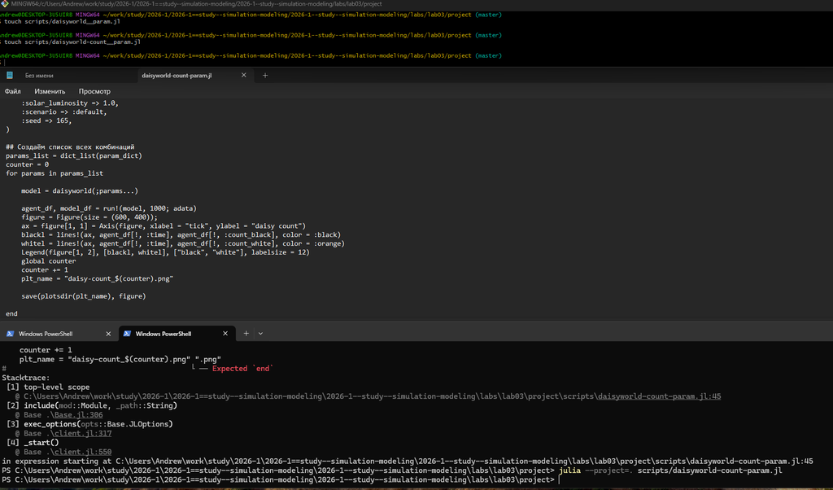

Динамика изменения числа маргариток с параметрами

Преобразовываем код в произвольные стили, открываем jupyter файл. анализируем получившиеся графики,зависящие от наших заданных параметров

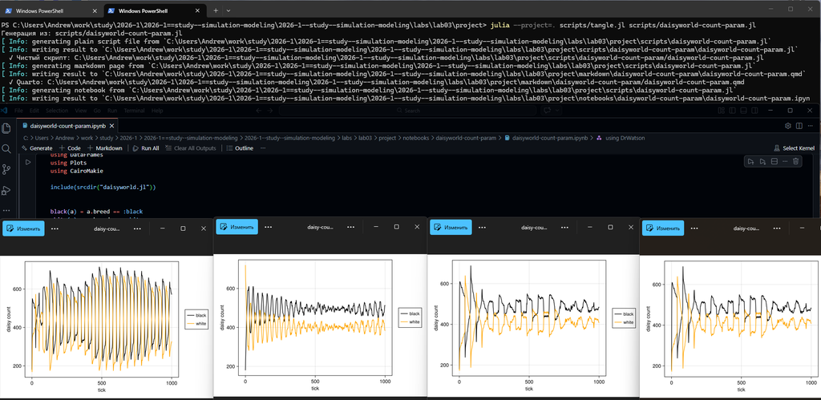

Код из jupyter notebook и графики динамики

Создаем, заполняем и запускаем файл, в котором можно построить комплексные графики, задав произвольные параметры

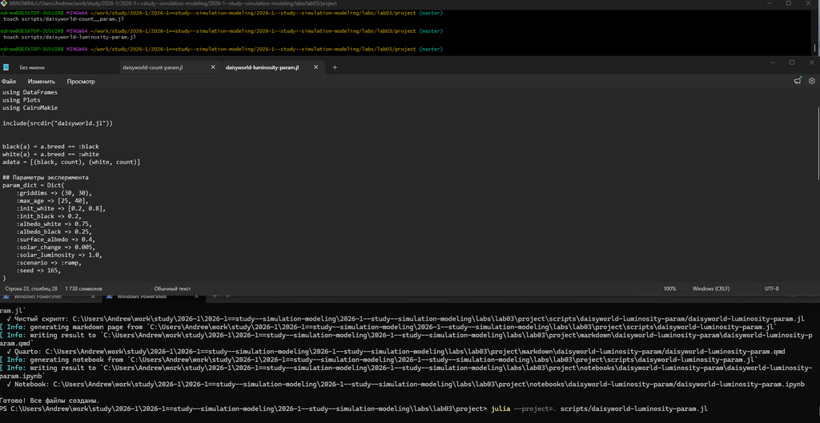

Файлы с комплексными графиками с параметрами

Преобразовываем код в произвольные стили, открываем jupyter файл. Анализируем получившиеся графики,зависящие от наших заданных параметров

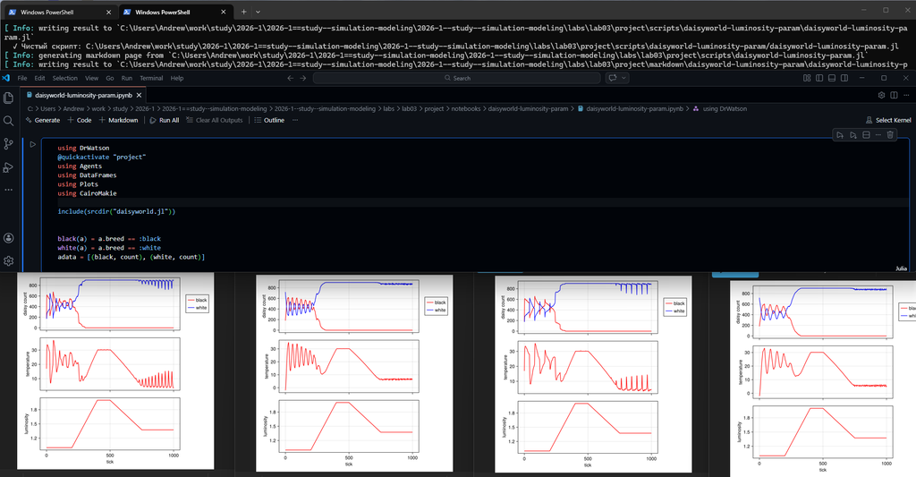

Код из jupyter notebook и комплексные графики

## Выводы

В данной работе мы разобрались с агентным моделированием и реализовали его на практике.